# Kickstarter Project - Logistics Regression / LDA Models Trainings

This notebook briefly walks through creating a Kickstarter project success prediction model using Logistic Regression and LDA.

First of all, we load all the necessary libraries.

```r
library(plyr)
library(MASS)
library(ROCR)
```

Define helpful function to get model accuracy, TPR, and FPR, and another function to plot ROC curve.

```r
# Print metrics about the model on accuracy,TPR and FPR
metrics <- function(tab) {
  print(paste("Accuracy is ",(tab[1,1] + tab[2,2]) / (tab[1,1] + tab[1,2] + tab[2,1] + tab[2,2])))
  print(paste("TPR is ", (tab[2,2]) / (tab[2,1] + tab[2,2]) ))
  print(paste("FPR is ", (tab[1,1]) / (tab[1,1] + tab[1,2]) ))
}
# Plot the roc curve for the model
roc <- function(rocr.lda.pred,color) {
perf <- performance(rocr.lda.pred, "tpr", "fpr")
plot(perf, col=color,add= TRUE)
abline(0, 1)
as.numeric(performance(rocr.lda.pred, "auc")@y.values)
}
```

Then we load the train and validation data prepared in previous scripts.

```r
train <- readRDS('../rdata/df_initital_success_train.rds')
validate <- readRDS('../rdata/df_initital_success_validate.rds')
```

Let’s take a look at the baseline model metrics.

```r
# Baseline Model Metrics
# Predict everything equal to most frequently occuring outcome i.e. state = 1
table(validate$state)
```

```
   0    1
5994 7752
```

```r
print(paste("Accuracy is ",table(validate$state)[2]/(nrow(validate))))
```

```
[1] "Accuracy is  0.563945875163684"
```

```r
print(paste("TPR is ",1))
```

```
[1] "TPR is  1"
```

```r
print(paste("FPR is ",1))
```

```
[1] "FPR is  1"
```

A simple logistics regression model is trained using all the features available. The model is then evaluated with validation data.

```r
#Logistic Regression
#Model 1 - Includes all features
mdl1 <- glm(state ~ ., data=train, family="binomial")
```

```
glm.fit: fitted probabilities numerically 0 or 1 occurred
```

```r
summary(mdl1)
```

```
Call:
glm(formula = state ~ ., family = "binomial", data = train)

Deviance Residuals:
    Min       1Q   Median       3Q      Max
-6.5522  -0.8653   0.4056   0.8355   7.6988

Coefficients:
                                         Estimate Std. Error z value Pr(>|z|)
(Intercept)                            -3.493e+00  6.332e-02 -55.161  < 2e-16 ***
goal                                   -1.669e-05  4.200e-07 -39.735  < 2e-16 ***
category_cleancomics                    9.197e-01  4.293e-02  21.421  < 2e-16 ***
category_cleancrafts                    9.223e-03  4.545e-02   0.203 0.839216
category_cleandance                     1.854e+00  6.503e-02  28.512  < 2e-16 ***
category_cleandesign                    6.892e-01  4.393e-02  15.690  < 2e-16 ***
category_cleanfashion                   8.648e-02  3.975e-02   2.176 0.029585 *
category_cleanfilm                      4.459e-01  2.736e-02  16.300  < 2e-16 ***
category_cleanfood                      2.547e-02  3.215e-02   0.792 0.428286
category_cleangames                     5.281e-01  3.613e-02  14.616  < 2e-16 ***
category_cleanjournalism               -5.003e-01  5.453e-02  -9.174  < 2e-16 ***
category_cleanmusic                     5.003e-01  2.643e-02  18.927  < 2e-16 ***
category_cleanphotography               4.621e-01  4.367e-02  10.581  < 2e-16 ***
category_cleanpublishing                1.072e+00  3.195e-02  33.551  < 2e-16 ***
category_cleantechnology                2.313e-02  3.207e-02   0.721 0.470805
category_cleantheater                   1.569e+00  5.146e-02  30.501  < 2e-16 ***
launched_at_monthAug                   -2.601e-01  3.458e-02  -7.523 5.37e-14 ***
launched_at_monthDec                   -2.168e-02  3.957e-02  -0.548 0.583795
launched_at_monthFeb                    7.415e-02  3.604e-02   2.058 0.039627 *
launched_at_monthJan                    2.329e-02  3.641e-02   0.640 0.522324
launched_at_monthJul                   -3.649e-01  3.344e-02 -10.911  < 2e-16 ***
launched_at_monthJun                   -1.443e-01  3.486e-02  -4.140 3.47e-05 ***
launched_at_monthMar                    1.247e-01  3.493e-02   3.570 0.000357 ***
launched_at_monthMay                   -1.286e-01  3.454e-02  -3.723 0.000197 ***
launched_at_monthNov                   -1.860e-02  3.591e-02  -0.518 0.604583
launched_at_monthOct                   -2.226e-02  3.515e-02  -0.633 0.526486
launched_at_monthSep                   -3.805e-02  3.535e-02  -1.076 0.281710
created_to_launched_days                2.781e-04  6.618e-05   4.202 2.64e-05 ***
launched_to_deadline_days              -2.397e-02  5.764e-04 -41.589  < 2e-16 ***
launched_at_holiday1                    1.135e-01  5.442e-02   2.086 0.036974 *
deadline_holiday1                       9.345e-02  4.938e-02   1.892 0.058430 .
sp500_close_percent_change_launched_at  1.555e+00  8.304e-01   1.873 0.061090 .
unemployment_rate                       4.569e-01  5.772e-03  79.151  < 2e-16 ***
early.bird.frac                         3.632e+00  1.577e-01  23.029  < 2e-16 ***
limited.frac                           -4.856e-01  2.517e-02 -19.291  < 2e-16 ***
ship.intl1                              3.367e-01  1.650e-02  20.401  < 2e-16 ***
popularity                              3.957e-03  4.404e-04   8.986  < 2e-16 ***
median.tier.cost                       -1.521e-04  3.865e-05  -3.935 8.31e-05 ***
tier.low                                1.507e-01  2.897e-03  52.016  < 2e-16 ***
tier.med                                2.202e-01  4.114e-03  53.516  < 2e-16 ***
tier.high                               1.877e-02  8.082e-03   2.322 0.020243 *
---
Signif. codes:  0 ‘***’ 0.001 ‘**’ 0.01 ‘*’ 0.05 ‘.’ 0.1 ‘ ’ 1

(Dispersion parameter for binomial family taken to be 1)

    Null deviance: 151040  on 109967  degrees of freedom
Residual deviance: 115302  on 109927  degrees of freedom
AIC: 115384

Number of Fisher Scoring iterations: 9
```

```r
predTestLog <- predict(mdl1, newdata=validate, type="response")
metrics(table(validate$state, predTestLog>0.5))
```

```
[1] "Accuracy is  0.748508657063873"
[1] "TPR is  0.810758513931889"
[1] "FPR is  0.668001334668001"
```

The output of the regression analysis showed that pretty much all features are significant except for a few, namely some of the project categories, some of the launch months, `deadline_holiday`, and `sp500_close_percent_change_launched_at`. The model suggested that whether the Kickstarter project ends on a holiday or not would not impact the project success. The same could be said about the S&P 500 index.

Let’s take a look at the ROC curve for the logistic regression model.

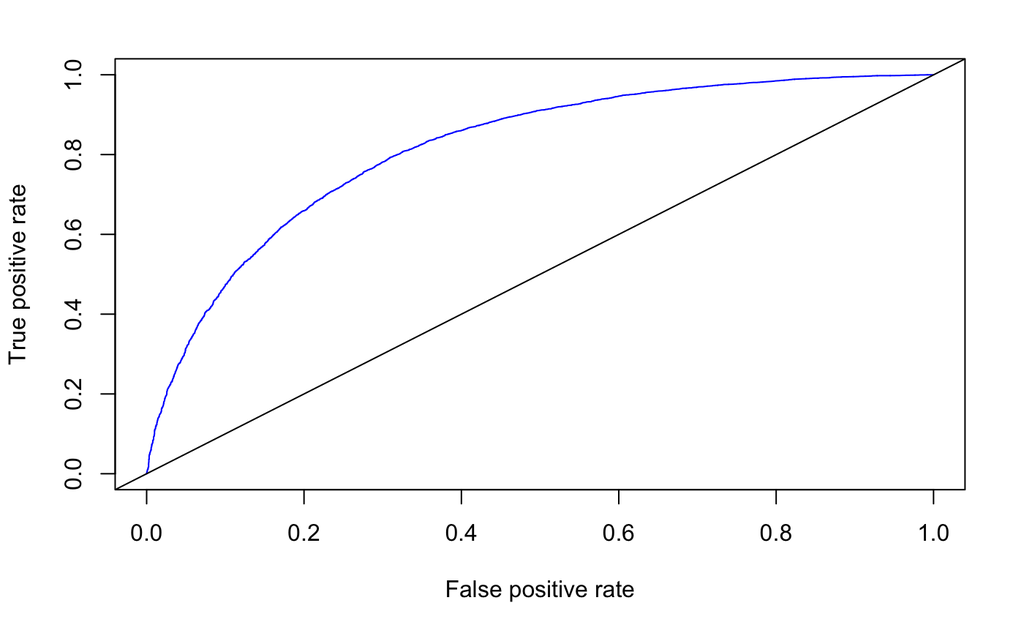

```r
tmp = prediction(predTestLog, validate$state)
perf <- performance(tmp, "tpr", "fpr")
plot(perf, col='blue')
abline(0, 1)
```

```r
as.numeric(performance(tmp, "auc")@y.values)
```

```
[1] 0.8154444
```

With two features found insignificant, a new logistics regression model is trained with those two features removed.

```r
#Model 2 - Remove insignificant features
mdl2 <- glm(state ~ . - deadline_holiday1 - sp500_close_percent_change_launched_at, data=train, family="binomial")
```

```
glm.fit: fitted probabilities numerically 0 or 1 occurred
```

```r
summary(mdl2)
```

```
Call:
glm(formula = state ~ . - deadline_holiday1 - sp500_close_percent_change_launched_at,
    family = "binomial", data = train)

Deviance Residuals:
    Min       1Q   Median       3Q      Max
-6.5526  -0.8649   0.4055   0.8358   7.6989

Coefficients:
                            Estimate Std. Error z value Pr(>|z|)
(Intercept)               -3.490e+00  6.331e-02 -55.133  < 2e-16 ***
goal                      -1.669e-05  4.200e-07 -39.738  < 2e-16 ***
category_cleancomics       9.205e-01  4.293e-02  21.441  < 2e-16 ***
category_cleancrafts       9.199e-03  4.545e-02   0.202 0.839608
category_cleandance        1.854e+00  6.503e-02  28.518  < 2e-16 ***
category_cleandesign       6.888e-01  4.392e-02  15.681  < 2e-16 ***
category_cleanfashion      8.634e-02  3.975e-02   2.172 0.029834 *
category_cleanfilm         4.460e-01  2.736e-02  16.301  < 2e-16 ***
category_cleanfood         2.536e-02  3.215e-02   0.789 0.430205
category_cleangames        5.278e-01  3.613e-02  14.611  < 2e-16 ***
category_cleanjournalism  -4.996e-01  5.453e-02  -9.162  < 2e-16 ***
category_cleanmusic        5.008e-01  2.643e-02  18.946  < 2e-16 ***
category_cleanphotography  4.620e-01  4.367e-02  10.579  < 2e-16 ***
category_cleanpublishing   1.072e+00  3.195e-02  33.557  < 2e-16 ***
category_cleantechnology   2.334e-02  3.207e-02   0.728 0.466729
category_cleantheater      1.570e+00  5.146e-02  30.504  < 2e-16 ***
launched_at_monthAug      -2.610e-01  3.457e-02  -7.548 4.43e-14 ***
launched_at_monthDec      -2.019e-02  3.955e-02  -0.511 0.609684
launched_at_monthFeb       7.896e-02  3.599e-02   2.194 0.028248 *
launched_at_monthJan       2.536e-02  3.635e-02   0.698 0.485455
launched_at_monthJul      -3.631e-01  3.344e-02 -10.860  < 2e-16 ***
launched_at_monthJun      -1.443e-01  3.485e-02  -4.141 3.46e-05 ***
launched_at_monthMar       1.262e-01  3.492e-02   3.613 0.000303 ***
launched_at_monthMay      -1.288e-01  3.454e-02  -3.728 0.000193 ***
launched_at_monthNov      -1.588e-02  3.590e-02  -0.442 0.658293
launched_at_monthOct      -1.837e-02  3.512e-02  -0.523 0.600874
launched_at_monthSep      -3.778e-02  3.534e-02  -1.069 0.285048
created_to_launched_days   2.777e-04  6.618e-05   4.196 2.72e-05 ***
launched_to_deadline_days -2.396e-02  5.763e-04 -41.571  < 2e-16 ***
launched_at_holiday1       1.237e-01  5.420e-02   2.282 0.022502 *
unemployment_rate          4.567e-01  5.771e-03  79.133  < 2e-16 ***
early.bird.frac            3.634e+00  1.577e-01  23.044  < 2e-16 ***
limited.frac              -4.856e-01  2.517e-02 -19.295  < 2e-16 ***
ship.intl1                 3.368e-01  1.650e-02  20.411  < 2e-16 ***
popularity                 3.944e-03  4.403e-04   8.957  < 2e-16 ***
median.tier.cost          -1.522e-04  3.865e-05  -3.937 8.26e-05 ***
tier.low                   1.507e-01  2.897e-03  52.011  < 2e-16 ***
tier.med                   2.202e-01  4.114e-03  53.530  < 2e-16 ***
tier.high                  1.882e-02  8.082e-03   2.329 0.019850 *
---
Signif. codes:  0 ‘***’ 0.001 ‘**’ 0.01 ‘*’ 0.05 ‘.’ 0.1 ‘ ’ 1

(Dispersion parameter for binomial family taken to be 1)

    Null deviance: 151040  on 109967  degrees of freedom
Residual deviance: 115309  on 109929  degrees of freedom
AIC: 115387

Number of Fisher Scoring iterations: 9
```

```r
predTestLog <- predict(mdl2, newdata=validate, type="response")
metrics(table(validate$state, predTestLog>0.5))
```

```
[1] "Accuracy is  0.748072166448421"
[1] "TPR is  0.809984520123839"
[1] "FPR is  0.668001334668001"
```

```r
tmp = prediction(predTestLog, validate$state)
perf <- performance(tmp, "tpr", "fpr")
as.numeric(performance(tmp, "auc")@y.values)
```

```
[1] 0.8154387
```

Not much of an improvement could be seen on accuracy, TPR, and FPR with the two features removed.

Next, instead of binomial, quasipoisson is used for the model, with all features included.

```r
#Model 3 - Model using quasipoisson
mdl3 <- glm(state ~ ., data=train, family="quasipoisson")
summary(mdl3)
```

```
Call:
glm(formula = state ~ ., family = "quasipoisson", data = train)

Deviance Residuals:
     Min        1Q    Median        3Q       Max
-10.2111   -0.8573    0.0536    0.4427    5.4836

Coefficients:
                                         Estimate Std. Error t value Pr(>|t|)
(Intercept)                            -1.857e+00  5.140e-01  -3.613 0.000303 ***
goal                                   -8.007e-06  3.680e-06  -2.176 0.029562 *
category_cleancomics                    2.999e-01  3.029e-01   0.990 0.322045
category_cleancrafts                   -1.352e-01  4.361e-01  -0.310 0.756574
category_cleandance                     5.035e-01  3.905e-01   1.290 0.197225
category_cleandesign                    2.353e-01  3.406e-01   0.691 0.489712
category_cleanfashion                  -9.663e-03  3.791e-01  -0.025 0.979662
category_cleanfilm                      1.898e-01  2.295e-01   0.827 0.408103
category_cleanfood                     -2.521e-02  3.019e-01  -0.084 0.933442
category_cleangames                     2.046e-01  2.876e-01   0.712 0.476720
category_cleanjournalism               -4.264e-01  5.856e-01  -0.728 0.466596
category_cleanmusic                     1.825e-01  2.175e-01   0.839 0.401553
category_cleanphotography               1.369e-01  3.772e-01   0.363 0.716681
category_cleanpublishing                3.387e-01  2.473e-01   1.369 0.170868
category_cleantechnology               -6.665e-02  3.078e-01  -0.216 0.828599
category_cleantheater                   4.308e-01  3.272e-01   1.317 0.187886
launched_at_monthAug                   -8.604e-02  2.800e-01  -0.307 0.758589
launched_at_monthDec                   -3.349e-02  3.183e-01  -0.105 0.916223
launched_at_monthFeb                    1.323e-02  2.798e-01   0.047 0.962274
launched_at_monthJan                   -1.950e-02  2.872e-01  -0.068 0.945882
launched_at_monthJul                   -1.324e-01  2.735e-01  -0.484 0.628340
launched_at_monthJun                   -3.627e-02  2.740e-01  -0.132 0.894698
launched_at_monthMar                    2.755e-02  2.698e-01   0.102 0.918656
launched_at_monthMay                   -2.691e-02  2.710e-01  -0.099 0.920883
launched_at_monthNov                   -1.995e-02  2.839e-01  -0.070 0.943971
launched_at_monthOct                   -7.827e-03  2.756e-01  -0.028 0.977345
launched_at_monthSep                   -3.419e-03  2.803e-01  -0.012 0.990267
created_to_launched_days                2.464e-04  5.205e-04   0.473 0.635902
launched_to_deadline_days              -7.956e-03  4.771e-03  -1.668 0.095404 .
launched_at_holiday1                    3.059e-02  4.216e-01   0.073 0.942149
deadline_holiday1                       3.487e-02  3.898e-01   0.089 0.928711
sp500_close_percent_change_launched_at  4.341e-01  6.401e+00   0.068 0.945928
unemployment_rate                       1.760e-01  4.577e-02   3.845 0.000121 ***
early.bird.frac                         1.512e+00  1.063e+00   1.422 0.155027
limited.frac                           -1.408e-01  2.160e-01  -0.652 0.514455
ship.intl1                              2.293e-01  1.393e-01   1.646 0.099834 .
popularity                              9.139e-04  3.302e-03   0.277 0.781961
median.tier.cost                       -1.486e-04  3.573e-04  -0.416 0.677563
tier.low                                2.130e-02  1.103e-02   1.931 0.053514 .
tier.med                                3.676e-02  1.737e-02   2.116 0.034345 *
tier.high                               9.999e-03  2.190e-02   0.457 0.647984
---
Signif. codes:  0 ‘***’ 0.001 ‘**’ 0.01 ‘*’ 0.05 ‘.’ 0.1 ‘ ’ 1

(Dispersion parameter for quasipoisson family taken to be 204.3167)

    Null deviance: 71732  on 109967  degrees of freedom
Residual deviance: 58265  on 109927  degrees of freedom
AIC: NA

Number of Fisher Scoring iterations: 8
```

```r
predTestLog <- predict(mdl3, newdata=validate, type="response")
metrics(table(validate$state, predTestLog>0.5))
```

```
[1] "Accuracy is  0.72959406372763"
[1] "TPR is  0.749355005159959"
[1] "FPR is  0.704037370704037"
```

```r
tmp = prediction(predTestLog, validate$state)
perf <- performance(tmp, "tpr", "fpr")
as.numeric(performance(tmp, "auc")@y.values)
```

```
[1] 0.8015722
```

Many features were seen as insignificant. A new model is created with the categories removed.

```r
#Model 4 - Model using quasipoisson without category (Remove insignificant features)
remove <- grep('category', names(train))
train_r <- train[-remove]
mdl4 <- glm(state ~ ., data=train_r, family="quasipoisson")
summary(mdl4)
```

```
Call:
glm(formula = state ~ ., family = "quasipoisson", data = train_r)

Deviance Residuals:
     Min        1Q    Median        3Q       Max
-10.3244   -0.8816    0.1041    0.4517    5.8098

Coefficients:
                                         Estimate Std. Error t value Pr(>|t|)
(Intercept)                            -1.816e+00  1.165e+00  -1.559   0.1189
goal                                   -8.887e-06  8.999e-06  -0.988   0.3234
launched_at_monthAug                   -9.785e-02  6.879e-01  -0.142   0.8869
launched_at_monthDec                   -4.409e-02  7.822e-01  -0.056   0.9550
launched_at_monthFeb                    1.166e-02  6.875e-01   0.017   0.9865
launched_at_monthJan                   -2.702e-02  7.057e-01  -0.038   0.9695
launched_at_monthJul                   -1.473e-01  6.716e-01  -0.219   0.8264
launched_at_monthJun                   -3.552e-02  6.733e-01  -0.053   0.9579
launched_at_monthMar                    2.534e-02  6.629e-01   0.038   0.9695
launched_at_monthMay                   -2.338e-02  6.658e-01  -0.035   0.9720
launched_at_monthNov                   -3.078e-02  6.975e-01  -0.044   0.9648
launched_at_monthOct                   -5.558e-03  6.773e-01  -0.008   0.9935
launched_at_monthSep                   -9.386e-03  6.889e-01  -0.014   0.9891
created_to_launched_days                2.618e-04  1.280e-03   0.204   0.8380
launched_to_deadline_days              -8.036e-03  1.166e-02  -0.689   0.4906
launched_at_holiday1                    4.375e-02  1.036e+00   0.042   0.9663
deadline_holiday1                       3.409e-02  9.582e-01   0.036   0.9716
sp500_close_percent_change_launched_at  4.794e-01  1.574e+01   0.030   0.9757
unemployment_rate                       1.920e-01  1.077e-01   1.782   0.0748 .
early.bird.frac                         1.352e+00  2.592e+00   0.522   0.6019
limited.frac                           -1.678e-01  5.265e-01  -0.319   0.7499
ship.intl1                              2.392e-01  3.346e-01   0.715   0.4746
popularity                              1.027e-03  8.099e-03   0.127   0.8991
median.tier.cost                       -1.602e-04  8.858e-04  -0.181   0.8565
tier.low                                2.317e-02  2.610e-02   0.888   0.3747
tier.med                                3.728e-02  4.266e-02   0.874   0.3821
tier.high                               8.899e-03  5.279e-02   0.169   0.8661
---
Signif. codes:  0 ‘***’ 0.001 ‘**’ 0.01 ‘*’ 0.05 ‘.’ 0.1 ‘ ’ 1

(Dispersion parameter for quasipoisson family taken to be 1234.321)

    Null deviance: 71732  on 109967  degrees of freedom
Residual deviance: 59801  on 109941  degrees of freedom
AIC: NA

Number of Fisher Scoring iterations: 8
```

```r
predTestLog <- predict(mdl4, newdata=validate, type="response")
metrics(table(validate$state, predTestLog>0.5))
```

```
[1] "Accuracy is  0.718099810854067"
[1] "TPR is  0.746646026831785"
[1] "FPR is  0.681181181181181"
```

```r
tmp = prediction(predTestLog, validate$state)
perf <- performance(tmp, "tpr", "fpr")
as.numeric(performance(tmp, "auc")@y.values)
```

```
[1] 0.7841377
```

Once again, not much improvement could be seen. Let’s compare ROC of all the models.

```r
# model 1 plot
predTestLog <- predict(mdl1, newdata=validate, type="response")
tmp = prediction(predTestLog, validate$state)
perf <- performance(tmp, "tpr", "fpr")
plot(perf, col='blue')
abline(0, 1)
```

```r
# model 2 plot
predTestLog <- predict(mdl2, newdata=validate, type="response")
roc(prediction(predTestLog, validate$state),'green')
```

```
[1] 0.8154387
```

```r
# model 3 plot
predTestLog <- predict(mdl3, newdata=validate, type="response")
roc(prediction(predTestLog, validate$state),'red')
```

```
[1] 0.8015722
```

```r
# model 4 plot
predTestLog <- predict(mdl4, newdata=validate, type="response")
roc(prediction(predTestLog, validate$state),'yellow')
```

```
[1] 0.7841377
```

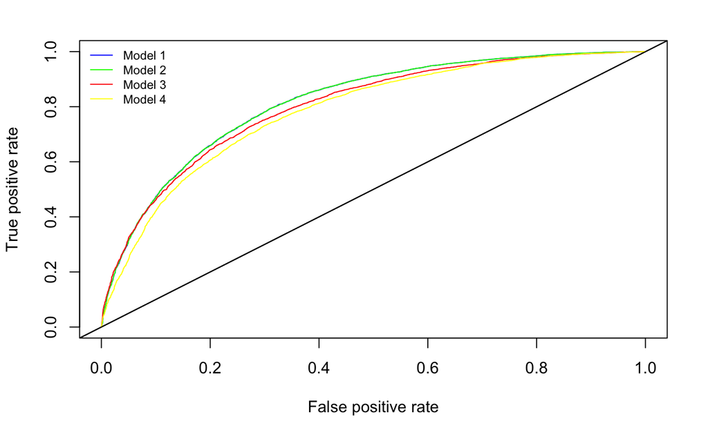

```r
legend('topleft', legend=c("Model 1", "Model 2","Model 3", "Model 4"),
       col=c("blue","green", "red", "yellow" ), lty=c(1,1), bty='n', cex=0.75)
```

Now, let’s take a look at using LDA to model project success.

```r
#LDA
lda_mod <- lda(state ~ ., data=train)
pred_test_lda_m <- predict(lda_mod, newdata =  validate)
pred_test_lda_m_probs <- pred_test_lda_m$posterior[,2]
metrics(table(validate$state, pred_test_lda_m_probs>0.5))
```

```
[1] "Accuracy is  0.730030554343082"
[1] "TPR is  0.782894736842105"
[1] "FPR is  0.661661661661662"
```

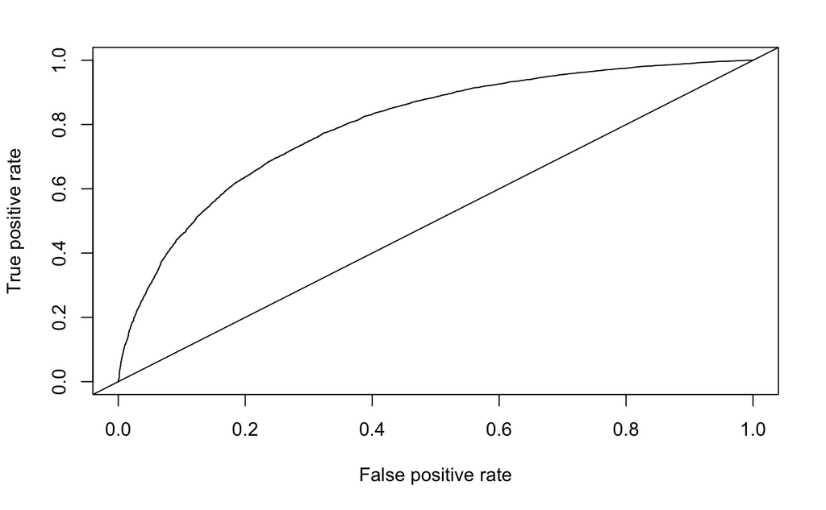

```r
rocr.lda.pred <- prediction(pred_test_lda_m_probs, validate$state)
perf <- performance(rocr.lda.pred, "tpr", "fpr")
plot(perf, col='black')
abline(0, 1)
```

```r
as.numeric(performance(rocr.lda.pred, "auc")@y.values)
```

```
[1] 0.7984984
```

LDA does not perform as well as model 2 of the logistics regression model.